# **Students Performance**: Data Exploration

## Introduction

The [dataset](https://www.kaggle.com/datasets/whenamancodes/students-performance-in-exams) used in this project is taken from Kaggle and it contains some information about students including their secured marks in a variety of subjects.

Variables:

- **gender**: The student's gender
- **race/ethnicity**: Race/Ethnicity of the student
- **parental level of education**: Level of education of the student's parents
- **lunch**: Indicates whether or not the student is having free or reduced lunch
- **test preparation**: Indicates whether or not the student has completed a test preparation course
- **math score**: The student's math score
- **reading score**: The student's reading score
- **writing score**: The student's writing score

## Preliminary Wrangling

```python
# import all packages and set plots to be embedded inline
import numpy as np
import pandas as pd
import matplotlib.pyplot as plt
import seaborn as sb
from pandas.api.types import CategoricalDtype

%matplotlib inline
```

```python
# loading the data
df = pd.read_csv('exams.csv')
```

```python
print(df.shape)
print(df.info())
df.head()
```

```
(1000, 8)
<class 'pandas.core.frame.DataFrame'>
RangeIndex: 1000 entries, 0 to 999
Data columns (total 8 columns):
 #   Column                       Non-Null Count  Dtype
---  ------                       --------------  -----
 0   gender                       1000 non-null   object
 1   race/ethnicity               1000 non-null   object
 2   parental level of education  1000 non-null   object
 3   lunch                        1000 non-null   object
 4   test preparation course      1000 non-null   object
 5   math score                   1000 non-null   int64
 6   reading score                1000 non-null   int64
 7   writing score                1000 non-null   int64
dtypes: int64(3), object(5)
memory usage: 62.6+ KB
None
```

|  | gender | race/ethnicity | parental level of education | lunch | test preparation course | math score | reading score | writing score |
| --- | --- | --- | --- | --- | --- | --- | --- | --- |
| 0 | male | group A | high school | standard | completed | 67 | 67 | 63 |
| 1 | female | group D | some high school | free/reduced | none | 40 | 59 | 55 |
| 2 | male | group E | some college | free/reduced | none | 59 | 60 | 50 |
| 3 | male | group B | high school | standard | none | 77 | 78 | 68 |
| 4 | male | group E | associate's degree | standard | completed | 78 | 73 | 68 |

```python
df.describe()
```

|  | math score | reading score | writing score |
| --- | --- | --- | --- |
| count | 1000.000000 | 1000.000000 | 1000.000000 |
| mean | 66.396000 | 69.002000 | 67.738000 |
| std | 15.402871 | 14.737272 | 15.600985 |
| min | 13.000000 | 27.000000 | 23.000000 |
| 25% | 56.000000 | 60.000000 | 58.000000 |
| 50% | 66.500000 | 70.000000 | 68.000000 |
| 75% | 77.000000 | 79.000000 | 79.000000 |
| max | 100.000000 | 100.000000 | 100.000000 |

```python
df.describe(include='O')
```

|  | gender | race/ethnicity | parental level of education | lunch | test preparation course |
| --- | --- | --- | --- | --- | --- |
| count | 1000 | 1000 | 1000 | 1000 | 1000 |
| unique | 2 | 5 | 6 | 2 | 2 |
| top | male | group C | some college | standard | none |
| freq | 517 | 323 | 222 | 652 | 665 |

As can be seen from the output shown above, The data is clean and tidy, However there are still some parts that can be improved to facilate working with the data later:

- Column names are long and contain spaces and special characters.
- Some column types are better converted into category.

```python
# Rename column names
df = df.rename(columns={"race/ethnicity":"race_ethnicity",
                        "parental level of education":"parents_education",
                        "test preparation course":"preparation_course",
                        "math score":"math_score",
                        "reading score":"reading_score",
                        "writing score":"writing_score"})
```

```python
# Convert categorical variables to category datatype
df.gender = df.gender.astype('category')
df.race_ethnicity = df.race_ethnicity.astype('category')
df.lunch = df.lunch.astype('category')
df.preparation_course = df.preparation_course.astype('category')

# Convert parents_education variable to ordred category datatype
education_lvls = ['some high school', 'high school', 'some college', "associate's degree", "bachelor's degree", "master's degree"]
df.parents_education = df.parents_education.astype(CategoricalDtype(education_lvls, ordered=True))
```

### What is/are the main feature(s) of interest in your dataset?

I'm most interested in figuring out what features are best for predicting the student's scores

### What features in the dataset do you think will help support your investigation into your feature(s) of interest?

I expect that all features can hold some interesting properties that can help in predicting student performance, but I think test preparation course and parental level of education will have the strongest effect on the students' scores in the 3 subjects.

## Univariate Exploration

```python
# Catogorical columns
categoric_vars = ['gender', 'race_ethnicity', 'parents_education', 'lunch', 'preparation_course']

# Numeric columns
numeric_vars = ['math_score', 'reading_score', 'writing_score']
```

I'll start by looking at the distribution of the main variables of interest: math_score, reading_score, and writing_score.

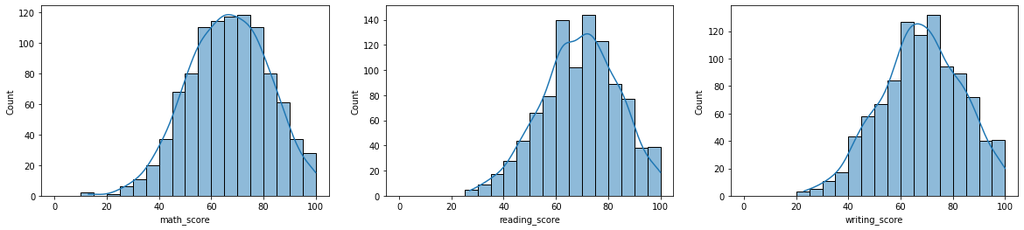

```python
fig, ax = plt.subplots(1,3, figsize=(20,4))

for i, var in enumerate(numeric_vars):
    # Choosing a bin size of 5
    bins = np.arange(0, 100+5, 5)
    sb.histplot(data=df, x=var, ax=ax[i], bins=bins, kde=True)
```

The 3 scores have a slightly left-skewed distribution with a peak between 60 and 80.  
Interestingly, there's a steep jump in frequency right before 100, rather than a smooth ramp-up.  
Since the scores are whole discrete numbers, let's shrink the bin size to 1 and regenerate the same plots to see if this was caused by a specific score in that last bin from the previous plot.

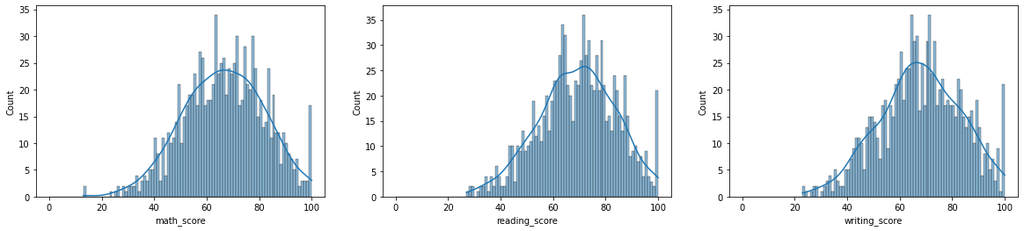

```python
fig, ax = plt.subplots(1,3, figsize=(20,4))

for i, var in enumerate(numeric_vars):
    # Choosing a bin size of 1
    bins = np.arange(0, 100+1, 1)
    sb.histplot(data=df, x=var, ax=ax[i], bins=bins, kde=True)
```

Surprisingly, It turned out that this steep jump in frequency was caused by the existence of a high number of students receiving the highest scores of 100.

Now, it's time to look at our predictor variables:  
Let's start with gender:

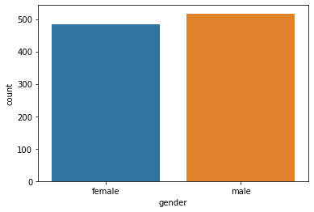

```python
sb.countplot(data=df, x='gender')
```

The number of males in this dataset is slightly greater than the number of females

Next up, race/ethenicity:

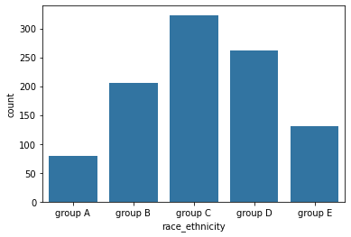

```python
default_color = sb.color_palette()[0]
sb.countplot(data=df, x='race_ethnicity', color=default_color);
```

Group C is the most frequent race ethnicity category, whereas group A is the least one.

Next parental educational level:

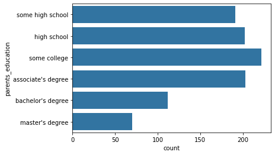

```python
sb.countplot(data=df, y='parents_education', color=default_color)
```

Some high school, high school, some college and associate's degree are the most frequent parental level of education, whereas more advanced levels such as bachelor's degree and master's degree are the least frequent.

Next variable lunch:

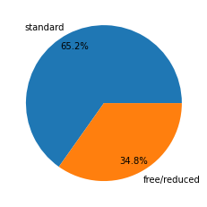

```python
group_lunch = df.lunch.value_counts()
labels = group_lunch.index
plt.pie(group_lunch, autopct='%1.1f%%', labels = labels, pctdistance = 0.83);
```

About one third of the students are having free or reduced lunch

Next preparation course:

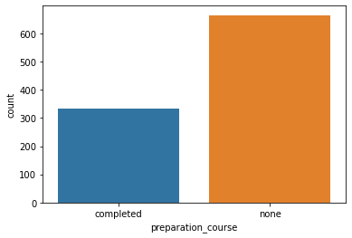

```python
sb.countplot(data=df, x='preparation_course',)
```

The number of students who completed the preparation course are about half the number of those who didn't

### Discuss the distribution(s) of your variable(s) of interest. Were there any unusual points? Did you need to perform any transformations?

The distribution of the 3 score variables appears to have a slightly left-skewed distribution, indicating the existence of some outliers with low scores.  
The jump in frequency at the end revealed the existence of a relatively high number of maximum scores achieved in the 3 subjects.

### Of the features you investigated, were there any unusual distributions? Did you perform any operations on the data to tidy, adjust, or change the form of the data? If so, why did you do this?

The investigation of the other variables was simple and straightforward since there wasn't any unusual distribution.

## Bivariate Exploration

In this section, we will investigate the relationships between pairs of variables in the dataset

First, let's take a quick look at the bivariate relationship between the numeric variables which are our variables of interest.

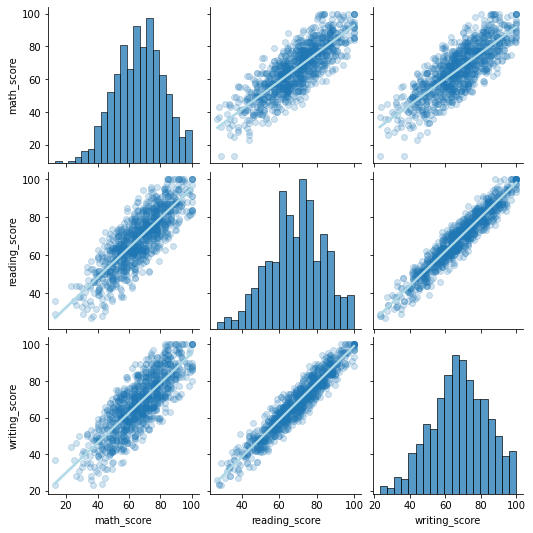

```python
line_kws = {'color':'lightblue'}
scatter_kws = {'alpha':0.2}
sb.pairplot(data=df, diag_kind='auto', kind='reg', plot_kws={'line_kws':line_kws,'scatter_kws':scatter_kws})
```

This pairplot shows a strong linear relationship between each couple of score variables, This relationship seems to be more important between reading score and writing score which is explained by points that seem to be more clustered around the line of best fit

Having no remarkable outliers, a heatmap might be able to demonstrate the correlation in a more straightforward and precise way.

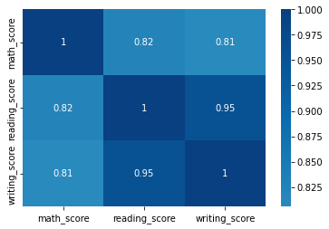

```python
ax = sb.heatmap(df.corr(), annot=True, cmap = 'GnBu', center=0.6,)
```

The above heatmap supports our previously discovered findings: the highest correlation between the 3 columns of interest is between writing and reading, this makes sense since both are scores of linguistic subjects

Now it's time to look at the relationship between our variables of interest and one of the other categorical variables.

**parents_education** vs **scores**

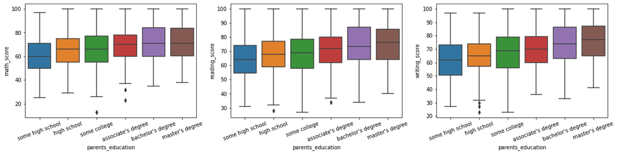

```python
fig, ax = plt.subplots(1,3, figsize=(20,4), sharex=False)

for i, var in enumerate(numeric_vars):
    sb.boxplot(data=df, x='parents_education', y=var, ax=ax[i] )
    ax[i].set_xticklabels(ax[i].get_xticklabels(), rotation = 20);
```

Here we can clearly see an increase in average scores in the 3 subjects across increasing parental level of education.

**lunch** vs **scores**

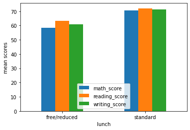

```python
df.groupby('lunch').mean().plot(kind='bar')
plt.ylabel('mean scores')
plt.xticks(rotation=0);
```

Students with standard lunch appear to perform better than those with free or reduced lunch.

**preparation_course** vs **scores**

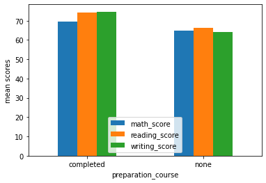

```python
df.groupby('preparation_course').mean().plot(kind='bar')
plt.ylabel('mean scores')
plt.xticks(rotation=0);
```

As it was expected, student who completed the preparation course are perofrming better than those who didn't.

**gender** vs **scores**

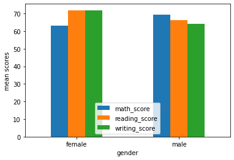

```python
df.groupby('gender').mean().plot(kind='bar')
plt.ylabel('mean scores')
plt.xticks(rotation=0);
```

The graph above shows that females perform better than males in reading and writing, whereas males perform better in mathematics.

**race_ethnicity** vs **scores**

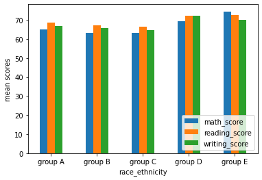

```python
df.groupby('race_ethnicity').mean().plot(kind='bar',)
plt.ylabel('mean scores')
plt.xticks(rotation=0);
plt.legend(loc='lower right')
```

The above plot doesn't show any outstanding properties except the fact that group D and group E scores are slightly better than other groups in the 3 subjects.

Now Let's take a look at the relationships between the independent features to see if there is any interesting relationship

```python
def stacked_bar(data, x, hue, hue_order, ax):
    ''' Quick hack for creating stacked plots '''
    dic={} # Empty dict
    sort = data[x].dtype.ordered == False
    for val in data[x].value_counts(sort=sort).index:
        dic[val]=data.query("{}==@val".format(x)).value_counts(hue)
    # Convert dict to dataframe
    new_df = pd.DataFrame(dic)
    new_df = new_df.rename_axis(None, axis=0)
    new_df = new_df.loc[hue_order]
    new_df = new_df.apply(lambda x: x/x.sum()) # convert records to percentages
    new_df.transpose().plot(kind='bar', stacked=True, ax=ax)
    # Rotate xtick labels
    ax.set_xticklabels(ax.get_xticklabels(), rotation=0)
    import matplotlib.ticker as mtick
    ax.yaxis.set_major_formatter(mtick.PercentFormatter()) #Format y axis as percent
    ax.legend(title=hue)
```

```python
def category_plot(data, x, hue):
    ''' generate two plots between two gategorical variables '''
    fig, ax = plt.subplots(1,2, figsize=(20,4))

    # Setting order for the x_axis variable
    if data[x].dtype.ordered==False:
        order= data[x].value_counts().index
    else:
        order=None

    # Setting the hue order to use across plots
    hue_order = data[hue].value_counts().index

    # Plot stacked_bar plto at the first axis
    stacked_bar(data, x, hue, hue_order, ax[0])

    # Plot countplot at the second axis
    sb.countplot(data=data, x=x, hue=hue, hue_order=hue_order , order=order, ax=ax[1],)
    ax[1].set_ylabel('count')
```

**race_ethnicity** vs **gender**

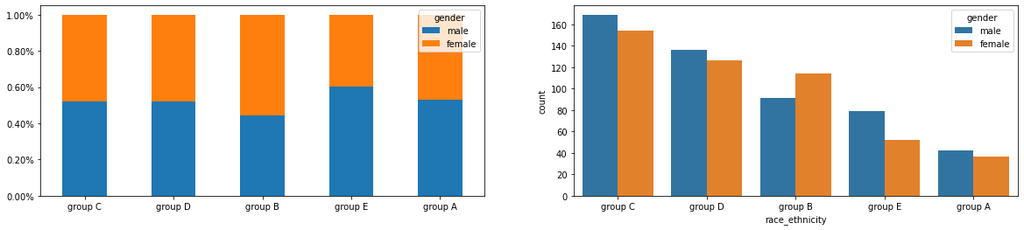

```python
category_plot(data=df, x='race_ethnicity', hue='gender')
```

As opposed to all race\ethnicity groups, the number of females in group B is greater than the number of males

**race_ethnicity** vs **preparation_course**

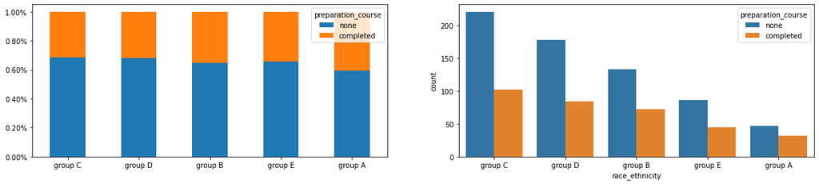

```python
category_plot(data=df, x='race_ethnicity', hue='preparation_course')
```

From this plot, we notice that the larger the race/ethnic group, the lower the percentage of completed preparation courses

**race_ethnicity** vs **lunch**

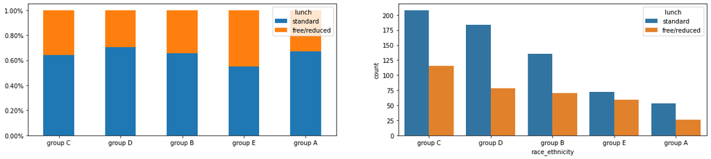

```python
category_plot(data=df, x='race_ethnicity', hue='lunch')
```

**parents_education** vs **gender**

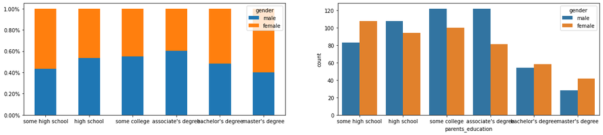

```python
category_plot(data=df, x='parents_education', hue='gender',)
```

**parents_education** vs **preparation_course**

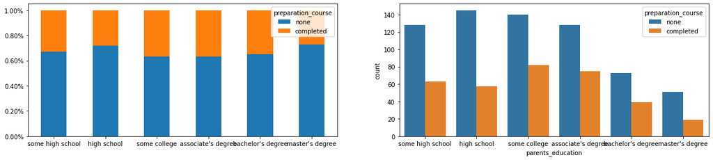

```python
category_plot(data=df, x='parents_education', hue='preparation_course',)
```

**parents_education** vs **lunch**

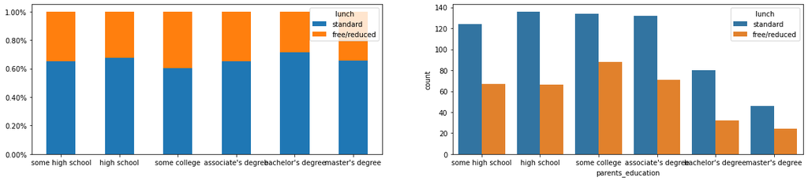

```python
category_plot(data=df, x='parents_education', hue='lunch',)
```

**race_ethnicity** vs **parents_education**

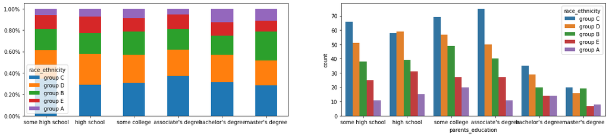

```python
category_plot(data=df, x='parents_education', hue='race_ethnicity')
```

**preparation_course** vs **lunch**

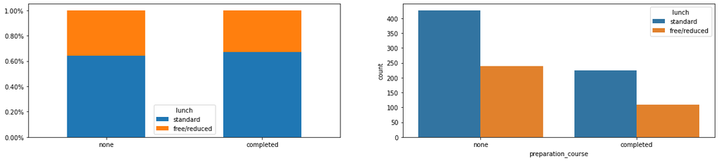

```python
category_plot(data=df, x='preparation_course', hue='lunch')
```

**preparation_course** vs **gender**

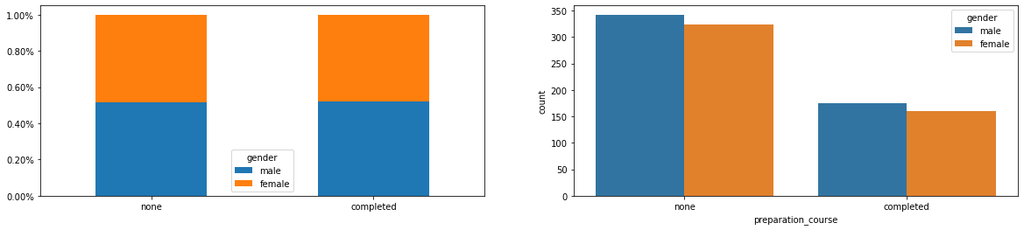

```python
category_plot(data=df, x='preparation_course', hue='gender')
```

**gender** vs **lunch**

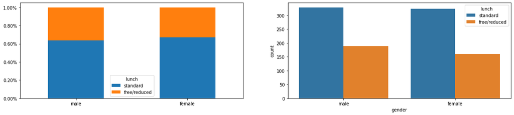

```python
category_plot(data=df, x='gender', hue='lunch')
```

### Did you observe any interesting relationships between the other features (not the main feature(s) of interest)?

As opposed to all race\ethnicity groups the number of females in group B is greater than the number of males.  
Another interesting thing that I discovered is the negative correlation between race/ethnic group size and the percentage of completed preparation courses.

## Multivariate Exploration

At this point, we've gone through the univariate analysis, then in the bivariate analysis, we have seen both the relationships between the variables of interest and their relationships with other variables.  
Now it's time to further our research by looking at multivariate relationships and see if we can spot any interaction effect.

We will start by looking at the relationship between our 3 variables of interest:

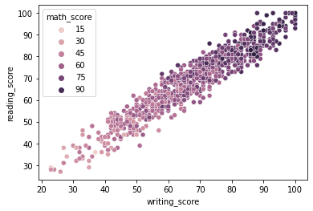

```python
sb.scatterplot(data=df, x='writing_score', y='reading_score', hue='math_score')
```

The linear relationship between each pair of score variables we've discovered during the bivariate analysis is clearly apparent here in a single plot.

Next, we'll try to explore how the ordinal categorical variable of parents_education plays into the relationship between scores and the preparation course variable

```python
def scores_barplots(data, x, hue):
    ''' Bar plots across numeric variables'''
    fig, ax = plt.subplots(1,3, figsize=(20,4))
    for i, var in enumerate(numeric_vars):
        sb.barplot(data =df, y=var, x=x, hue=hue, errwidth=0, ax=ax[i]);
        ax[i].get_legend().remove()
    ax[0].legend(loc='lower left', fontsize="small")
```

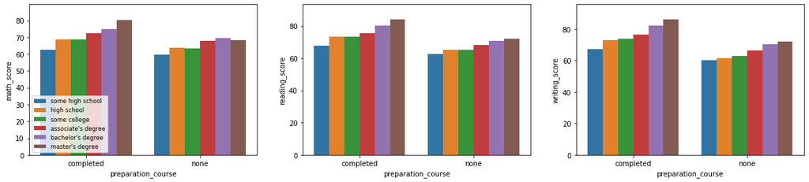

```python
scores_barplots(df, 'preparation_course', 'parents_education')
```

As we previously found, there is a positive correlation between the parental level of education and the students' performance, which was seen through an increase in the average scores with an increasing parental level of education, In this plot, we may notice a steeper increase with students who completed the preparation course.  
In order to emphasize the small changes in average score and see if there is truly a difference, a lineplot will be used next

```python
def scores_lineplots(data, x, hue=None):
    ''' Line plots across numeric variables'''
    fig, ax = plt.subplots(1,3, figsize=(20,4))
    for i, var in enumerate(numeric_vars):
        sb.lineplot(data =df, y=var, x=x, hue=hue, err_style=None, ax=ax[i], marker='.', markersize=12);
        ax[i].tick_params(axis='x', labelrotation = 20)
```

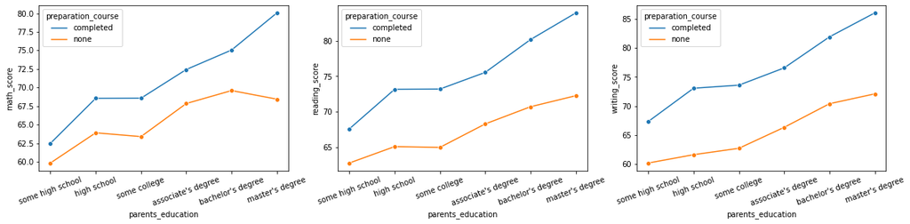

```python
scores_lineplots(data=df, x='parents_education', hue='preparation_course')
```

After adding the preparation course as a third variable, we can notice from the line chart above that the correlation between the parental level of education and scores is slightly stronger for students who have completed the preparation course than those who didn't, which suggest a positive correlation between the preparation course effectiveness and the parental level of education.

Let's now see if gender plays any role in this relationship

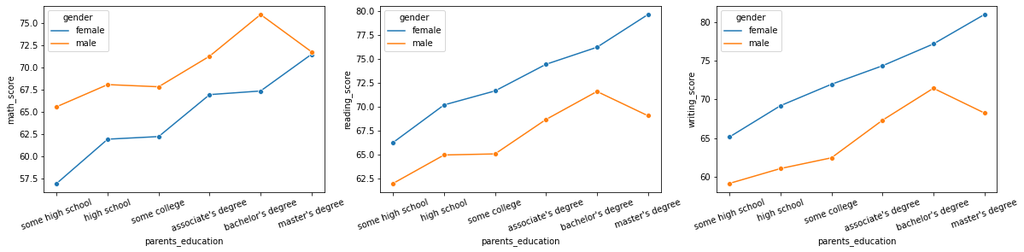

```python
scores_lineplots(data=df, x='parents_education', hue='gender')
```

Males performance line chart across the parental level of education has the same shape in the 3 different subjects with a peak at bachelor's degree.  
Equally, females' performance line chart shows a similar shape for the 3 subjects with a consistently increasing trend.

What about lunch?

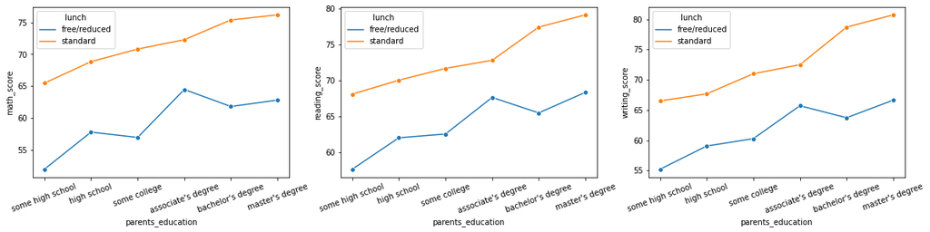

```python
scores_lineplots(data=df, x='parents_education', hue='lunch')
```

Similar to gender, for the same lunch type the performance line charts keep a very similar shape for each score.

Next, we will investigate other multiple relationships

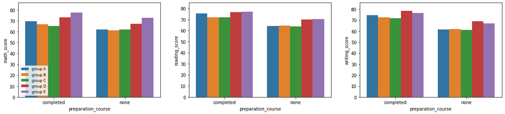

```python
scores_barplots(df, 'preparation_course', 'race_ethnicity')
```

Race/ethnicity group doesn't seem to have any effect on the relationship between scores and preparation course

**preparation_course** and **lunch**

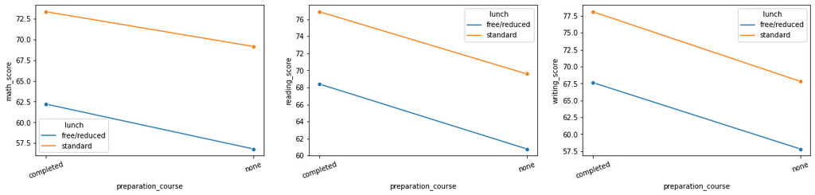

```python
scores_lineplots(data=df, x='preparation_course', hue='lunch')
```

**preparation_course** and **gender**

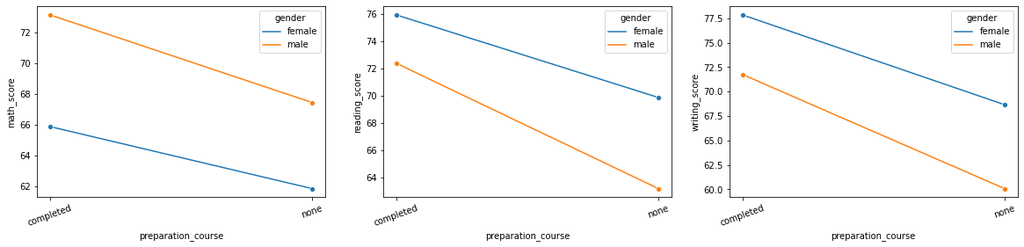

```python
scores_lineplots(data=df, x='preparation_course', hue='gender')
```

**lunch** and **gender**

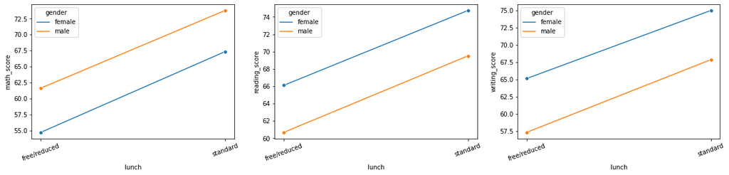

```python
scores_lineplots(data=df, x='lunch', hue='gender')
```

The lines in the above plots are basically parallel indicating the absence of an interaction effect

### Talk about some of the relationships you observed in this part of the investigation. Were there features that strengthened each other in terms of looking at your feature(s) of interest?

The first thing I discovered in this part was the strong correlation between the three variables of interest, this means that using a subject score as a predictive variable will be really helpful in predicting the other scores. The correlation between the parental level of education and each subject score seemed to be slightly stronger for students who completed the preparation course.

### Were there any interesting or surprising interactions between features?

Surprisingly, I discovered that for the same gender and across all subjects, the trend between student performance and parental level of education remains very similar, this behavior also holds true for the same lunch option.